# Classification of Forest Cover Type

Ada Kiekhaefer

3/18/2020

### Goal of the Study

To predict forest cover types from given features (observations of 30 x 30 meter cell). The seven forest cover type are:

Forest Cover Type Classes:  
1. Spruce/Fir 2. Lodgepole Pine 3. Ponderosa Pine 4. Cottonwood/Willow 5. Aspen 6. Douglas-fir 7. Krummholz

#### Numeric Features

- Elevation: Elevation in meters
- Aspect: Aspect in degrees azimuth
- Slope: Slope in degrees
- Horizontal_Distance_To_Hydrology: Horz Dist to nearest surface water in meters
- Vertical_Distance_To_Hydrology: Vert Dist to nearest surface water in meters
- Horizontal_Distance_To_Roadways: Horz Dist to nearest roadway in meters
- Hillshade_9am: Hillshade index at 9am, summer solstice (0 to 255 index)
- Hillshade_Noon: Hillshade index at noon, summer soltice (0 to 255 index)
- Hillshade_3pm: Hillshade index at 3pm, summer solstice (0 to 255 index)
- Horizontal_Distance_To_Fire_Points: Horz Dist to nearest wildfire ignition points in meters

#### Categorical Features

- Wilderness_Area (4 binary columns): 0 (absence) or 1 (presence) Wilderness area designation
- Soil_Type (40 binary columns): 0 (absence) or 1 (presence)
- Cover_Type (7 types): Forest Cover Type designation (1 to 7)

### Exploratory Data Analysis

#### Load libraries

```r
library(dplyr)
library(readr)
```

#### Load data

- The data file was in csv format. I used read_csv function from readr package to load it into R.
- Unfortuanely, none of the columns were labeled.

```r
df <- read_csv('./data/covtype.data', col_names=FALSE)
```

```r
#Looking at the first few rows of the data
df %>% head()
```

```
## # A tibble: 6 x 55
##      X1    X2    X3    X4    X5    X6    X7    X8    X9   X10   X11   X12
##   <dbl> <dbl> <dbl> <dbl> <dbl> <dbl> <dbl> <dbl> <dbl> <dbl> <dbl> <dbl>
## 1  2596    51     3   258     0   510   221   232   148  6279     1     0
## 2  2590    56     2   212    -6   390   220   235   151  6225     1     0
## 3  2804   139     9   268    65  3180   234   238   135  6121     1     0
## 4  2785   155    18   242   118  3090   238   238   122  6211     1     0
## 5  2595    45     2   153    -1   391   220   234   150  6172     1     0
## 6  2579   132     6   300   -15    67   230   237   140  6031     1     0
## # … with 43 more variables: X13 <dbl>, X14 <dbl>, X15 <dbl>, X16 <dbl>,
## #   X17 <dbl>, X18 <dbl>, X19 <dbl>, X20 <dbl>, X21 <dbl>, X22 <dbl>,
## #   X23 <dbl>, X24 <dbl>, X25 <dbl>, X26 <dbl>, X27 <dbl>, X28 <dbl>,
## #   X29 <dbl>, X30 <dbl>, X31 <dbl>, X32 <dbl>, X33 <dbl>, X34 <dbl>,
## #   X35 <dbl>, X36 <dbl>, X37 <dbl>, X38 <dbl>, X39 <dbl>, X40 <dbl>,
## #   X41 <dbl>, X42 <dbl>, X43 <dbl>, X44 <dbl>, X45 <dbl>, X46 <dbl>,
## #   X47 <dbl>, X48 <dbl>, X49 <dbl>, X50 <dbl>, X51 <dbl>, X52 <dbl>,
## #   X53 <dbl>, X54 <dbl>, X55 <dbl>
```

#### Add column names

- I added column names based on the information in covtype.info.

```r
temp_name <- c('Elevation', 'Aspect', 'Slope', 'Horizontal_Distance_To_Hydrology',
               'Vertical_Distance_To_Hydrology','Horizontal_Distance_To_Roadways',
               'Hillshade_9am', 'Hillshade_Noon', 'Hillshade_3pm',
               'Horizontal_Distance_To_Fire_Points', 'Wilderness_Area1',
               'Wilderness_Area2', 'Wilderness_Area3','Wilderness_Area4')

# create soil column names
num <-1:40
soil_name <- paste('Soil_Type', num, sep='')
col_names <- c(temp_name, soil_name, 'Cover_Type')

# add column names to the dataframe
colnames(df) <- col_names
```

#### Check data structure

- Check the structure of the dataset. All the columns were loaded in as numeric. I will change Cover_Type to categorical.

```r
df %>%
  glimpse()
```

```
## Observations: 581,012
## Variables: 55
## $ Elevation                          <dbl> 2596, 2590, 2804, 2785, 2595,…
## $ Aspect                             <dbl> 51, 56, 139, 155, 45, 132, 45…
## $ Slope                              <dbl> 3, 2, 9, 18, 2, 6, 7, 4, 9, 1…
## $ Horizontal_Distance_To_Hydrology   <dbl> 258, 212, 268, 242, 153, 300,…
## $ Vertical_Distance_To_Hydrology     <dbl> 0, -6, 65, 118, -1, -15, 5, 7…
## $ Horizontal_Distance_To_Roadways    <dbl> 510, 390, 3180, 3090, 391, 67…
## $ Hillshade_9am                      <dbl> 221, 220, 234, 238, 220, 230,…
## $ Hillshade_Noon                     <dbl> 232, 235, 238, 238, 234, 237,…
## $ Hillshade_3pm                      <dbl> 148, 151, 135, 122, 150, 140,…
## $ Horizontal_Distance_To_Fire_Points <dbl> 6279, 6225, 6121, 6211, 6172,…
## $ Wilderness_Area1                   <dbl> 1, 1, 1, 1, 1, 1, 1, 1, 1, 1,…
## $ Wilderness_Area2                   <dbl> 0, 0, 0, 0, 0, 0, 0, 0, 0, 0,…
## $ Wilderness_Area3                   <dbl> 0, 0, 0, 0, 0, 0, 0, 0, 0, 0,…
```

[output cut: 42 more lines]

#### Explore the data

- There are 581,012 observations, 55 columns in the dataset including the response variable (Cover_Type).
- Cover_Type: the response variable
- 54 features: 10 numeric and 44 categorical features
  - 10 numeric features:
  - 40 Soil_Type: 40 soil types in 40 columns
  - 4 Wilderness_Area:
    1. Rawah
    2. Neota
    3. Comanche Peak
    4. Cache la Poudre

#### Check for missing values

- No missing value in this dataset.

```r
any(is.na(df))
```

```
## [1] FALSE
```

#### Change Cover_Type to categorical

```r
df <- df %>%
  mutate_each(funs(factor), "Cover_Type")
```

### 1. Describe the dataset and any interesting variables (feel free to include response).

Hint: It may be useful to provide a high-level summary (i.e. descriptive statistics) on the variables

(The summary statistics are shown below)

#### Summary statistics of numeric features

```r
library(psych)

df %>%
  select(Elevation:Horizontal_Distance_To_Fire_Points) %>%
  describe()
```

```
##                                    vars      n    mean      sd median
## Elevation                             1 581012 2959.37  279.98   2996
## Aspect                                2 581012  155.66  111.91    127
## Slope                                 3 581012   14.10    7.49     13
## Horizontal_Distance_To_Hydrology      4 581012  269.43  212.55    218
## Vertical_Distance_To_Hydrology        5 581012   46.42   58.30     30
## Horizontal_Distance_To_Roadways       6 581012 2350.15 1559.25   1997
## Hillshade_9am                         7 581012  212.15   26.77    218
## Hillshade_Noon                        8 581012  223.32   19.77    226
## Hillshade_3pm                         9 581012  142.53   38.27    143
## Horizontal_Distance_To_Fire_Points   10 581012 1980.29 1324.20   1710
##                                    trimmed     mad  min  max range  skew
## Elevation                          2983.39  259.45 1859 3858  1999 -0.82
## Aspect                              150.10  126.02    0  360   360  0.40
## Slope                                13.49    7.41    0   66    66  0.79
## Horizontal_Distance_To_Hydrology    243.88  197.19    0 1397  1397  1.14
## Vertical_Distance_To_Hydrology       37.56   40.03 -173  601   774  1.79
## Horizontal_Distance_To_Roadways    2203.24 1541.90    0 7117  7117  0.71
## Hillshade_9am                       215.09   23.72    0  254   254 -1.18
## Hillshade_Noon                      225.11   17.79    0  254   254 -1.06
## Hillshade_3pm                       143.36   37.06    0  254   254 -0.28
## Horizontal_Distance_To_Fire_Points 1797.61 1111.95    0 7173  7173  1.29
##                                    kurtosis   se
## Elevation                              0.75 0.37
## Aspect                                -1.22 0.15
## Slope                                  0.58 0.01
## Horizontal_Distance_To_Hydrology       1.37 0.28
## Vertical_Distance_To_Hydrology         5.25 0.08
## Horizontal_Distance_To_Roadways       -0.38 2.05
## Hillshade_9am                          1.88 0.04
## Hillshade_Noon                         2.07 0.03
## Hillshade_3pm                          0.40 0.05
## Horizontal_Distance_To_Fire_Points     1.65 1.74
```

#### Summary statistics of categorical features

```r
df %>%
  select(Wilderness_Area1:Soil_Type40) %>%
  describe()
```

```
##                  vars      n mean   sd min max range se
## Wilderness_Area1    1 581012 0.45 0.50   0   1     1  0
## Wilderness_Area2    2 581012 0.05 0.22   0   1     1  0
## Wilderness_Area3    3 581012 0.44 0.50   0   1     1  0
## Wilderness_Area4    4 581012 0.06 0.24   0   1     1  0
## Soil_Type1          5 581012 0.01 0.07   0   1     1  0
## Soil_Type2          6 581012 0.01 0.11   0   1     1  0
## Soil_Type3          7 581012 0.01 0.09   0   1     1  0
## Soil_Type4          8 581012 0.02 0.14   0   1     1  0
## Soil_Type5          9 581012 0.00 0.05   0   1     1  0
## Soil_Type6         10 581012 0.01 0.11   0   1     1  0
## Soil_Type7         11 581012 0.00 0.01   0   1     1  0
## Soil_Type8         12 581012 0.00 0.02   0   1     1  0
## Soil_Type9         13 581012 0.00 0.04   0   1     1  0
## Soil_Type10        14 581012 0.06 0.23   0   1     1  0
## Soil_Type11        15 581012 0.02 0.14   0   1     1  0
## Soil_Type12        16 581012 0.05 0.22   0   1     1  0
## Soil_Type13        17 581012 0.03 0.17   0   1     1  0
## Soil_Type14        18 581012 0.00 0.03   0   1     1  0
## Soil_Type15        19 581012 0.00 0.00   0   1     1  0
## Soil_Type16        20 581012 0.00 0.07   0   1     1  0
## Soil_Type17        21 581012 0.01 0.08   0   1     1  0
## Soil_Type18        22 581012 0.00 0.06   0   1     1  0
## Soil_Type19        23 581012 0.01 0.08   0   1     1  0
## Soil_Type20        24 581012 0.02 0.13   0   1     1  0
## Soil_Type21        25 581012 0.00 0.04   0   1     1  0
## Soil_Type22        26 581012 0.06 0.23   0   1     1  0
## Soil_Type23        27 581012 0.10 0.30   0   1     1  0
## Soil_Type24        28 581012 0.04 0.19   0   1     1  0
## Soil_Type25        29 581012 0.00 0.03   0   1     1  0
## Soil_Type26        30 581012 0.00 0.07   0   1     1  0
## Soil_Type27        31 581012 0.00 0.04   0   1     1  0
## Soil_Type28        32 581012 0.00 0.04   0   1     1  0
## Soil_Type29        33 581012 0.20 0.40   0   1     1  0
## Soil_Type30        34 581012 0.05 0.22   0   1     1  0
## Soil_Type31        35 581012 0.04 0.21   0   1     1  0
## Soil_Type32        36 581012 0.09 0.29   0   1     1  0
## Soil_Type33        37 581012 0.08 0.27   0   1     1  0
## Soil_Type34        38 581012 0.00 0.05   0   1     1  0
## Soil_Type35        39 581012 0.00 0.06   0   1     1  0
## Soil_Type36        40 581012 0.00 0.01   0   1     1  0
## Soil_Type37        41 581012 0.00 0.02   0   1     1  0
## Soil_Type38        42 581012 0.03 0.16   0   1     1  0
## Soil_Type39        43 581012 0.02 0.15   0   1     1  0
## Soil_Type40        44 581012 0.02 0.12   0   1     1  0
```

### 2. Provide up to 5 key insights that you learned from this dataset

(The plots are shown below)

1. Cover_Type: Class 1 has the ratio of 0.365 and and Class 2 has the ratio of 0.488 (see code below). These two cover types account for 85.3% of all observations.

```r
#ratio of Cover_Type
df %>%
  group_by(Cover_Type) %>%
  summarise(n=n()) %>%
  mutate(freq = round(n/sum(n),3))
```

```
## # A tibble: 7 x 3
##   Cover_Type      n  freq
##   <fct>       <int> <dbl>
## 1 1          211840 0.365
## 2 2          283301 0.488
## 3 3           35754 0.062
## 4 4            2747 0.005
## 5 5            9493 0.016
## 6 6           17367 0.03
## 7 7           20510 0.035
```

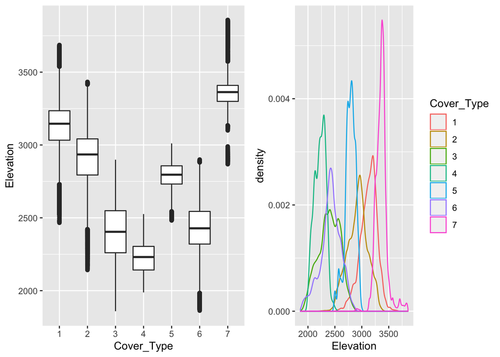

```r
library(ggplot2)
library(gridExtra)
#boxplot of Elevation versus cover type, each cover type has median at different elevation
p1 <- ggplot(df, aes(x=Cover_Type, y=Elevation)) +
  geom_boxplot()
#density plot of elevation versus cover type (overlap of elevation, can't build model with this feature alone)
p2 <- ggplot(df, aes(x=Elevation, color=Cover_Type), alpha=0.05) +
  geom_density()

grid.arrange(p1, p2, ncol = 2)
```

3. Some features are highly correlated. Horizontal_Distance_To_Hydrology has high possitive correlation with Vertical_Distance_To_Hydrology. Hillshade_3pm has high positive correlation with Aspect but has high negative corelation with Hillshade_9am.

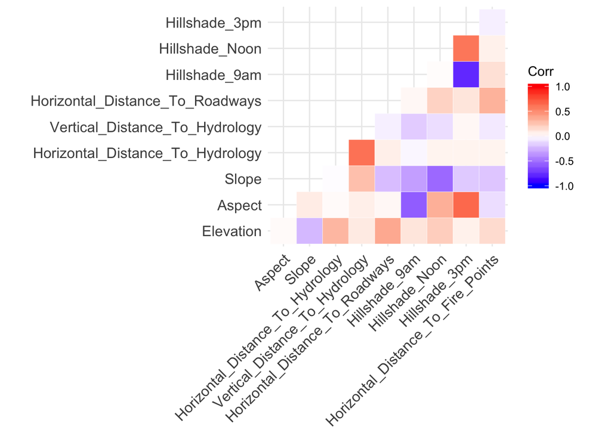

```r
#correlation of numeric features
#subset dataframe, remove categorical variables
df_sub <- df %>%
  select(-starts_with("Soil"), -starts_with("Wild"), -'Cover_Type')

#calculate correlations among numeric features
df_sub_corr <- df_sub %>%
  cor()

#loading library for correlation plot
library(ggcorrplot)

#correlation plot
df_sub_corr %>% ggcorrplot(type = "lower", outline.col = "white")
```

4. Most observations of class 3,4,5,6 seem to have lower Horizontal_Distance_To_Roadways than class 1,2,7. Class 4 seems to have lowest Horizontal_Distance_To_Hydrology.

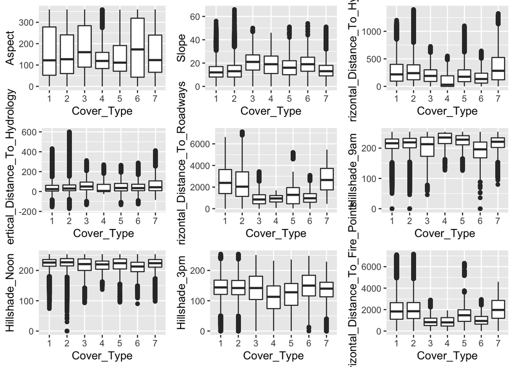

```r
#boxplot of Aspect versus cover type
p3 <- ggplot(df, aes(x=Cover_Type, y=Aspect)) +
  geom_boxplot()

#boxplot of slope versus cover type
p4 <- ggplot(df, aes(x=Cover_Type, y=Slope)) +
  geom_boxplot()

#boxplot of Horizontal_Distance_To_Hydrology versus cover type
p5 <- ggplot(df, aes(x=Cover_Type, y=Horizontal_Distance_To_Hydrology)) +
  geom_boxplot()

#boxplot of Vertical_Distance_To_Hydrology versus cover type
p6 <- ggplot(df, aes(x=Cover_Type, y=Vertical_Distance_To_Hydrology)) +
  geom_boxplot()

#boxplot of Horizontal_Distance_To_Roadways versus cover type
p7 <- ggplot(df, aes(x=Cover_Type, y=Horizontal_Distance_To_Roadways)) +
  geom_boxplot()

#boxplot of Hillshade_9am versus cover type (0 = darkest area, 255 = brightest area)
p8 <- ggplot(df, aes(x=Cover_Type, y=Hillshade_9am)) +
  geom_boxplot()

#boxplot of Hillshade_Noon versus cover type (0 = darkest area, 255 = brightest area)
p9 <- ggplot(df, aes(x=Cover_Type, y=Hillshade_Noon)) +
  geom_boxplot()

#boxplot of Hillshade_3pm versus cover type (0 = darkest area, 255 = brightest area)
p10 <- ggplot(df, aes(x=Cover_Type, y=Hillshade_3pm)) +
  geom_boxplot()

#boxplot of Horizontal_Distance_To_Fire_Points versus cover type
p11 <- ggplot(df, aes(x=Cover_Type, y=Horizontal_Distance_To_Fire_Points)) +
  geom_boxplot()

grid.arrange(p3,p4,p5,p6,p7,p8,p9,p10,p11 , ncol = 3)
```

### 3. Highlight challenges in the dataset and the plans to mitigate those challenges

(Hint: If there are missing data, how would you address this?)

- The features have different characteristics i.e. mean, spread, and range. This may effect the model. Some algorithms are sensitive to high values. Feature scaling can help mitigate this issue.
- The dataset has more than 500k observations and 54 features. Some algorithm may take a long time to run. I can mitigate this problem by.
  - Feature selection: take out some features that do not effect model performance
  - Subset the data (but still keep enough observations for each cover type)
- Some features are highly correlated. This can be mitigated by removing some correlated features.
- The dataset has no missing data. If there are missing data, how would you address this?
  - if there aren’t too many data missing compare to numbers of observations, remove rows with missing data
  - if the effect of that column isn’t significant for a model, remove the whole column
  - imputation, replace missing data with median (median imputation) or kNN imputation. With this dataset, I would choose kNN imputation because forest usually cover large area (bigger than 30x30 meters).
  - keep missing data as ‘missing’ category: coarse classification

### Feature Engineering

- Here, I used Z-score standardization. It is useful when the data have some outliers and measurments are in different scales of magnitude. The scaled features have mean of zero and variance of 1.

```
new_feature = (x - mean(x))/sd
```

```r
#features scaling: scale numeric features to range 0 to 1
#load caret package
library(caret)
processed_var <- preProcess(df %>% select(Elevation:Horizontal_Distance_To_Fire_Points), method = c('center', 'scale'))
df_scaled <- predict(processed_var, df)

#creat new feature called Distance_To_Hydrology, drop Horizontal_Distance_To_Hydrology and Vertical_Distance_To_Hydrology
# Distance_To_Hydrology = sqrt(Horizontal_Distance_To_Hydrology^2 + Vertical_Distance_To_Hydrology^2)

df_scaled %>% select(Elevation:Horizontal_Distance_To_Fire_Points) %>% summary()
```

```
##    Elevation           Aspect            Slope
##  Min.   :-3.9301   Min.   :-1.3909   Min.   :-1.8834
##  1st Qu.:-0.5370   1st Qu.:-0.8726   1st Qu.:-0.6816
##  Median : 0.1308   Median :-0.2561   Median :-0.1474
##  Mean   : 0.0000   Mean   : 0.0000   Mean   : 0.0000
##  3rd Qu.: 0.7273   3rd Qu.: 0.9324   3rd Qu.: 0.5203
##  Max.   : 3.2096   Max.   : 1.8259   Max.   : 6.9304
##  Horizontal_Distance_To_Hydrology Vertical_Distance_To_Hydrology
##  Min.   :-1.2676                  Min.   :-3.7639
##  1st Qu.:-0.7595                  1st Qu.:-0.6762
##  Median :-0.2420                  Median :-0.2817
##  Mean   : 0.0000                  Mean   : 0.0000
##  3rd Qu.: 0.5390                  3rd Qu.: 0.3874
##  Max.   : 5.3050                  Max.   : 9.5133
##  Horizontal_Distance_To_Roadways Hillshade_9am     Hillshade_Noon
##  Min.   :-1.5072                 Min.   :-7.9248   Min.   :-11.2966
##  1st Qu.:-0.7979                 1st Qu.:-0.5284   1st Qu.: -0.5220
##  Median :-0.2265                 Median : 0.2187   Median :  0.1356
##  Mean   : 0.0000                 Mean   : 0.0000   Mean   :  0.0000
##  3rd Qu.: 0.6271                 3rd Qu.: 0.7043   3rd Qu.:  0.6921
##  Max.   : 3.0571                 Max.   : 1.5635   Max.   :  1.5520
##  Hillshade_3pm      Horizontal_Distance_To_Fire_Points
##  Min.   :-3.72384   Min.   :-1.4955
##  1st Qu.:-0.61472   1st Qu.:-0.7222
##  Median : 0.01232   Median :-0.2041
##  Mean   : 0.00000   Mean   : 0.0000
##  3rd Qu.: 0.66550   3rd Qu.: 0.4302
##  Max.   : 2.91243   Max.   : 3.9214
```

#### Split train/test set

I split train/test set to 75% and 25% of the total data, respectively.

```r
#load rsample package
library(rsample)
#spliting data to train and test sets
set.seed(20)
df_split <- initial_split(df_scaled, prop = 0.75)
df_train <- training(df_split)
df_test <- testing(df_split)
```

### Model Straegy

#### 1. What model(s) are you using and why?

- Multinomial Logistic Regression: First, I started with Multinomial Logistic Regression because it’s a simple model, didn’t take too much time to run, and easy to interpret.
- Random Forest:
  - Gives better performance
  - Easy to train and tune

#### 2. Describe (in detail) how each model was developed.

- First, I started training MLR the with only two features. Just to see the how long it take to run.

```r
library(nnet)

start_time <- Sys.time()
model_log <- multinom(Cover_Type ~ Elevation + Horizontal_Distance_To_Roadways,
                      data = df_train)
end_time <- Sys.time()

print(paste('run time : ', end_time - start_time))
```

```
## [1] "run time :  32.1924049854279"
```

- Next, check the model summary.

```r
print(model_log)
```

```
## Call:
## multinom(formula = Cover_Type ~ Elevation + Horizontal_Distance_To_Roadways,
##     data = df_train)
##
## Coefficients:
##   (Intercept) Elevation Horizontal_Distance_To_Roadways
## 2   0.7876337 -2.002228                       0.1070754
## 3  -6.2301723 -6.837302                       0.6843566
## 4 -11.7318379 -8.829010                       2.5838522
## 5  -3.1907167 -2.674982                      -0.7894355
## 6  -6.5215874 -6.705923                       0.8697754
## 7  -6.5721229  3.976008                       0.1332291
##
## Residual Deviance: 663875.8
## AIC: 663911.8
```

- Make prediction with test dataset

```r
pred <- predict(model_log, df_test)
```

- Look at confusion matrix

```r
con_mat_test <- confusionMatrix(pred, df_test$Cover_Type)
print(con_mat_test)
```

```
## Confusion Matrix and Statistics
##
##           Reference
## Prediction     1     2     3     4     5     6     7
##          1 34690 14348     0     0     0     0  4074
##          2 17414 55199  2657     1  2420  1194    24
##          3    12  1078  6378   694    32  3068     0
##          4     0     0     0     0     0     0     0
##          5     0     0     0     0     0     0     0
##          6     0     0     0     0     0     0     0
##          7   947     6     0     0     0     0  1017
##
## Overall Statistics
##
##                Accuracy : 0.6698
##                  95% CI : (0.6673, 0.6722)
##     No Information Rate : 0.4863
##     P-Value [Acc > NIR] : < 2.2e-16
##
##                   Kappa : 0.4468
##
##  Mcnemar's Test P-Value : NA
##
## Statistics by Class:
##
##                      Class: 1 Class: 2 Class: 3 Class: 4 Class: 5 Class: 6
## Sensitivity            0.6538   0.7815  0.70592 0.000000  0.00000  0.00000
## Specificity            0.8002   0.6823  0.96415 1.000000  1.00000  1.00000
## Pos Pred Value         0.6531   0.6995  0.56633      NaN      NaN      NaN
## Neg Pred Value         0.8006   0.7674  0.98017 0.995215  0.98312  0.97066
## Prevalence             0.3653   0.4863  0.06220 0.004785  0.01688  0.02934
## Detection Rate         0.2388   0.3800  0.04391 0.000000  0.00000  0.00000
## Detection Prevalence   0.3657   0.5433  0.07753 0.000000  0.00000  0.00000
## Balanced Accuracy      0.7270   0.7319  0.83503 0.500000  0.50000  0.50000
##                      Class: 7
## Sensitivity          0.198827
## Specificity          0.993200
## Pos Pred Value       0.516244
## Neg Pred Value       0.971399
## Prevalence           0.035214
## Detection Rate       0.007002
## Detection Prevalence 0.013563
## Balanced Accuracy    0.596013
```

- As expected, the model with only two features didn’t do very well.
- Try training the model with all features

```r
start_time <- Sys.time()
model_log_all <- multinom(Cover_Type ~ ., data = df_train)
end_time <- Sys.time()

print(paste('run time : ', end_time - start_time))
```

```
## [1] "run time :  5.07641021807988"
```

```r
print(model_log_all)
```

```
## Call:
## multinom(formula = Cover_Type ~ ., data = df_train)
##
## Coefficients:
##   (Intercept) Elevation      Aspect      Slope
## 2  -0.9363797 -2.624470 -0.02982184  0.1934695
## 3  -3.2917280 -5.060238  0.08113139  0.4465178
## 4  -2.5060552 -3.600720  0.78124098  1.4799371
## 5  -8.8979365 -3.224003  0.13319167  0.6757542
## 6  -2.6328643 -4.173942  0.01049747  1.6468359
## 7  -0.3391832  2.351594  0.21967356 -0.1744521
##   Horizontal_Distance_To_Hydrology Vertical_Distance_To_Hydrology
## 2                       0.40835422                    -0.04712547
## 3                       0.65401491                     0.19888677
## 4                      -1.53235625                     1.16211261
```

[output cut: 76 more lines]

- Make prediction with test dataset

```r
pred_all <- predict(model_log_all, df_test)
```

- Look at confusion matrix

```r
con_mat <- confusionMatrix(pred_all, df_test$Cover_Type)

print(con_mat)
```

```
## Confusion Matrix and Statistics
##
##           Reference
## Prediction     1     2     3     4     5     6     7
##          1 37996 14458     0     0     6     0  2125
##          2 13783 54938  1001     2  2345  1279     1
##          3     3  1027  7687   525    90  2569    23
##          4     0    10   130   149     1    57     0
##          5     0     0     0     0     4     0     0
##          6     5    99   217    19     6   357     0
##          7  1276    99     0     0     0     0  2966
##
## Overall Statistics
##
##                Accuracy : 0.7167
##                  95% CI : (0.7143, 0.719)
##     No Information Rate : 0.4863
##     P-Value [Acc > NIR] : < 2.2e-16
##
##                   Kappa : 0.5362
##
##  Mcnemar's Test P-Value : NA
##
## Statistics by Class:
##
##                      Class: 1 Class: 2 Class: 3 Class: 4  Class: 5
## Sensitivity            0.7161   0.7778  0.85080 0.214388 1.631e-03
## Specificity            0.8201   0.7533  0.96890 0.998630 1.000e+00
## Pos Pred Value         0.6961   0.7490  0.64467 0.429395 1.000e+00
## Neg Pred Value         0.8338   0.7818  0.98989 0.996232 9.831e-01
## Prevalence             0.3653   0.4863  0.06220 0.004785 1.688e-02
## Detection Rate         0.2616   0.3782  0.05292 0.001026 2.754e-05
## Detection Prevalence   0.3758   0.5050  0.08209 0.002389 2.754e-05
## Balanced Accuracy      0.7681   0.7655  0.90985 0.606509 5.008e-01
##                      Class: 6 Class: 7
## Sensitivity          0.083763  0.57986
## Specificity          0.997546  0.99019
## Pos Pred Value       0.507824  0.68325
## Neg Pred Value       0.972985  0.98475
## Prevalence           0.029342  0.03521
## Detection Rate       0.002458  0.02042
## Detection Prevalence 0.004840  0.02989
## Balanced Accuracy    0.540655  0.78503
```

```r
#print results for each class
print(con_mat$byClass)
```

```
##          Sensitivity Specificity Pos Pred Value Neg Pred Value Precision
## Class: 1 0.716054501   0.8200564      0.6960887      0.8338223 0.6960887
## Class: 2 0.777817106   0.7532765      0.7489945      0.7817507 0.7489945
## Class: 3 0.850802435   0.9688954      0.6446662      0.9898897 0.6446662
## Class: 4 0.214388489   0.9986303      0.4293948      0.9962320 0.4293948
## Class: 5 0.001631321   1.0000000      1.0000000      0.9831462 1.0000000
## Class: 6 0.083763491   0.9975459      0.5078236      0.9729851 0.5078236
## Class: 7 0.579863148   0.9901882      0.6832527      0.9847493 0.6832527
##               Recall          F1  Prevalence Detection Rate
## Class: 1 0.716054501 0.705930440 0.365314314   2.615850e-01
## Class: 2 0.777817106 0.763133769 0.486261902   3.782228e-01
## Class: 3 0.850802435 0.733527363 0.062201813   5.292145e-02
## Class: 4 0.214388489 0.285988484 0.004784755   1.025796e-03
## Class: 5 0.001631321 0.003257329 0.016880891   2.753816e-05
## Class: 6 0.083763491 0.143806647 0.029341907   2.457781e-03
## Class: 7 0.579863148 0.627326565 0.035214419   2.041954e-02
##          Detection Prevalence Balanced Accuracy
## Class: 1         3.757926e-01         0.7680555
## Class: 2         5.049741e-01         0.7655468
## Class: 3         8.209125e-02         0.9098489
## Class: 4         2.388935e-03         0.6065094
## Class: 5         2.753816e-05         0.5008157
## Class: 6         4.839831e-03         0.5406547
## Class: 7         2.988579e-02         0.7850257
```

#### Train a random forest model

```r
set.seed(64)
tunegrid <- expand.grid(.mtry=14,
                        .splitrule="gini",
                        .min.node.size=1)
model_ran3 <- train(Cover_Type ~ ., tuneLength = 1,
                    data = df_train,
                    method = 'ranger',
                    tuneGrid = tunegrid,
                    # num.trees = 500,
                    # importance = 'permutation',
                    trControl = trainControl(method = 'cv',
                                             number = 2,
                                             verboseIter = TRUE))
```

```
## Computing prediction error.. Progress: 82%. Estimated remaining time: 6 seconds.
```

```r
print(model_ran3)
```

```
## Random Forest
##
## 435759 samples
##     54 predictor
##      7 classes: '1', '2', '3', '4', '5', '6', '7'
##
## No pre-processing
## Resampling: Cross-Validated (2 fold)
## Summary of sample sizes: 217879, 217880
## Resampling results:
##
##   Accuracy   Kappa
##   0.9416191  0.9056479
##
## Tuning parameter 'mtry' was held constant at a value of 14
##
## Tuning parameter 'splitrule' was held constant at a value of gini
##
## Tuning parameter 'min.node.size' was held constant at a value of 1
```

- Make a prediction

```r
pred_ran3 <- predict(model_ran3, df_test)
con_mat_ran3 <- confusionMatrix(pred_ran3, df_test$Cover_Type)

print(con_mat_ran3)
```

```
## Confusion Matrix and Statistics
##
##           Reference
## Prediction     1     2     3     4     5     6     7
##          1 50329  1454     0     0    25     1   223
##          2  2603 68829   133     0   434    96    27
##          3     1   158  8708    67    44   311     0
##          4     0     0    37   610     0    16     0
##          5    13    85     3     0  1941     1     0
##          6     1    78   154    18     8  3837     0
##          7   116    27     0     0     0     0  4865
##
## Overall Statistics
##
##                Accuracy : 0.9578
##                  95% CI : (0.9567, 0.9588)
##     No Information Rate : 0.4863
##     P-Value [Acc > NIR] : < 2.2e-16
##
##                   Kappa : 0.932
##
##  Mcnemar's Test P-Value : NA
##
## Statistics by Class:
##
##                      Class: 1 Class: 2 Class: 3 Class: 4 Class: 5 Class: 6
## Sensitivity            0.9485   0.9745  0.96381 0.877698  0.79160  0.90028
## Specificity            0.9815   0.9559  0.99573 0.999633  0.99929  0.99816
## Pos Pred Value         0.9673   0.9543  0.93745 0.920060  0.95007  0.93677
## Neg Pred Value         0.9707   0.9754  0.99759 0.999412  0.99643  0.99699
## Prevalence             0.3653   0.4863  0.06220 0.004785  0.01688  0.02934
## Detection Rate         0.3465   0.4739  0.05995 0.004200  0.01336  0.02642
## Detection Prevalence   0.3582   0.4965  0.06395 0.004564  0.01407  0.02820
## Balanced Accuracy      0.9650   0.9652  0.97977 0.938666  0.89544  0.94922
##                      Class: 7
## Sensitivity           0.95112
## Specificity           0.99898
## Pos Pred Value        0.97145
## Neg Pred Value        0.99822
## Prevalence            0.03521
## Detection Rate        0.03349
## Detection Prevalence  0.03448
## Balanced Accuracy     0.97505
```

```r
#print results for each class
print(con_mat_ran3$byClass)
```

```
##          Sensitivity Specificity Pos Pred Value Neg Pred Value Precision
## Class: 1   0.9484763   0.9815273      0.9672701      0.9706718 0.9672701
## Class: 2   0.9744871   0.9558709      0.9543413      0.9753593 0.9543413
## Class: 3   0.9638074   0.9957348      0.9374529      0.9975950 0.9374529
## Class: 4   0.8776978   0.9996334      0.9200603      0.9994121 0.9200603
## Class: 5   0.7915987   0.9992857      0.9500734      0.9964318 0.9500734
## Class: 6   0.9002816   0.9981630      0.9367676      0.9969892 0.9367676
## Class: 7   0.9511241   0.9989796      0.9714457      0.9982174 0.9714457
##             Recall        F1  Prevalence Detection Rate
## Class: 1 0.9484763 0.9577811 0.365314314    0.346491983
## Class: 2 0.9744871 0.9643090 0.486261902    0.473855962
## Class: 3 0.9638074 0.9504475 0.062201813    0.059950569
## Class: 4 0.8776978 0.8983800 0.004784755    0.004199569
## Class: 5 0.7915987 0.8636263 0.016880891    0.013362891
## Class: 6 0.9002816 0.9181622 0.029341907    0.026415978
## Class: 7 0.9511241 0.9611775 0.035214419    0.033493284
##          Detection Prevalence Balanced Accuracy
## Class: 1           0.35821635         0.9650018
## Class: 2           0.49652675         0.9651790
## Class: 3           0.06395049         0.9797711
## Class: 4           0.00456445         0.9386656
## Class: 5           0.01406511         0.8954422
## Class: 6           0.02819907         0.9492223
## Class: 7           0.03447777         0.9750519
```

### Results

#### 1. Describe your model results

Multinomial Logistic Regression: * Accuracy, Precision, and Recall of all classes are shown in black solid, blue dotted, and dashed red lines, respectively. * The MLR model yielded overall acccuracy of 71.67% with accuracy of each class ranging between 0.50 (Class 5) - 0.91 (Class 3). The precision of all classes range between 0.43 (Class 4) - 1 (Class 5) and recall range between 0.002 (Class 5) - 0.85 (Class 3). The model has very low recall of class 4,5, and 6.

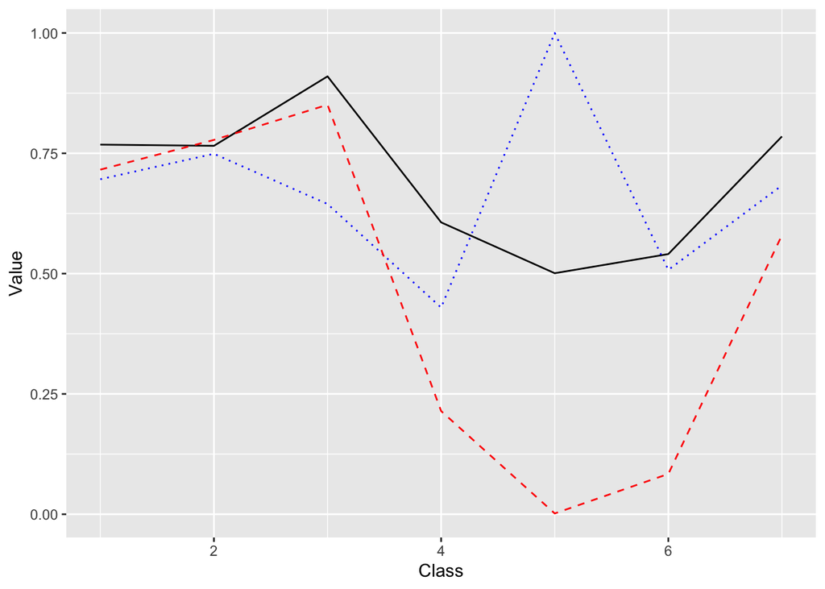

```r
log_byclass <- data.frame(con_mat$byClass)
log_byclass %>%
  ggplot() +
  geom_line(aes(x=1:7, y= Balanced.Accuracy), color='Black') +
  geom_line(aes(x=1:7, y=Precision), color='Blue', linetype = 'dotted') +
  geom_line(aes(x=1:7, y=Recall), color='Red', linetype='dashed') +
  scale_color_discrete(name = 'Y series', breaks = c('Precision', 'Recall')) +
  labs(x = 'Class', y = 'Value')
```

Random Forest: * Improve accuracy of decision tree model by fitting many trees * Fit each one to a boostrap sample of the data, called boostrap aggregation or bagging * Randomly sample columns at each split * The random forest model (cv = 2, mtry = 14) has overall accuracy of 95.8% with accuracy of each class ranging between 0.90 (Class 5) - 0.98 (Class 3). The precision of all classes range between 0.92 (Class 4) - 0.97 (Class 7) and recall range between 0.79 (Class 5) - 0.97 (Class 2). The recall of Class 5 is lowest at 0.79 * Class 5 seems to have lowest accuracy and recall from both models.

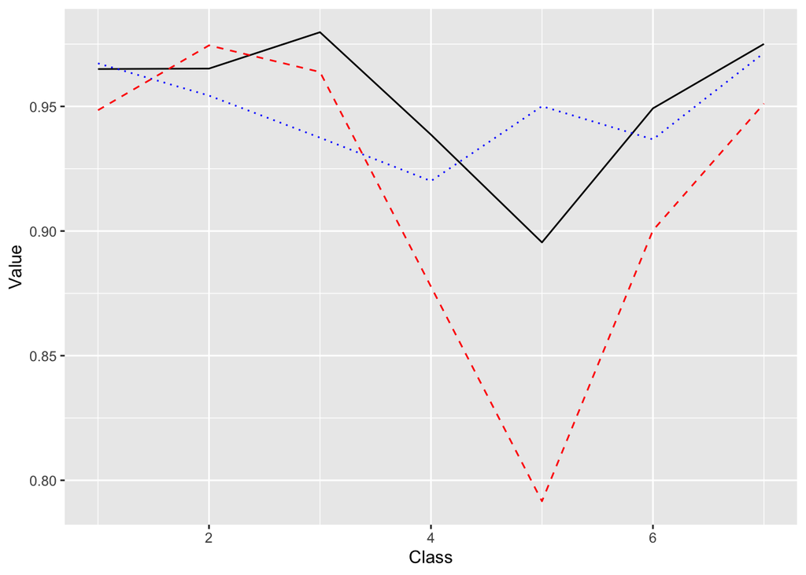

```r
ran_byclass <- data.frame(con_mat_ran3$byClass)
ran_byclass %>%
  ggplot() +
  geom_line(aes(x=1:7, y= Balanced.Accuracy), color='Black') +
  geom_line(aes(x=1:7, y=Precision), color='Blue', linetype='dotted') +
  geom_line(aes(x=1:7, y=Recall), color='Red', linetype='dashed') +
  scale_color_discrete(name = "", breaks = c("Balanced.Accuracy", "Precision", "Recall")) +
  labs(x = 'Class', y = 'Value')
```

#### 3. If more time were provided, what other strategies would you pursue? Why?

- Hyperparameters tuning of random forest model
- Explore different models
- Variable selection / feature importance